# Part II - Loan Prosper Dataset Investigation

## by Chelsea Moore

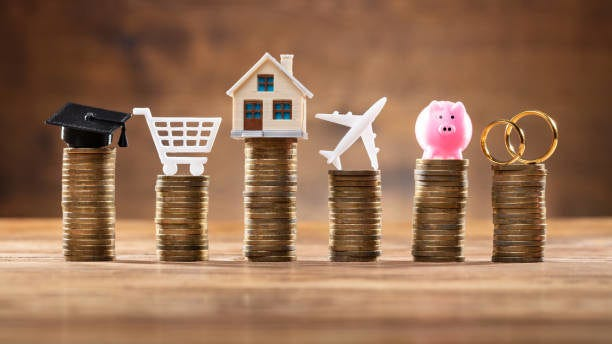

## Investigation Overview

> Presentation Objectives:
1. What the dataset is made up of & the distribution of the variables in the dataset.
2. Assess the relationships between the variables in the dataset
3. Which variable influence the Prosper Score and Interest Rate APR.

## Dataset Overview

> The data consists of information about 113,937 loans granted by Prosper. This includes the Prosper score, listing category (loan type), employment status, number of current credit lines, number of open revolving accounts, debt to income ratio, and original loan amount. The list is extensive.

## Overview: Loan Category & Application Employment Status

> Most applications for loans were for Debt Consolidation

> Majority of the applicants were employed and earning an income

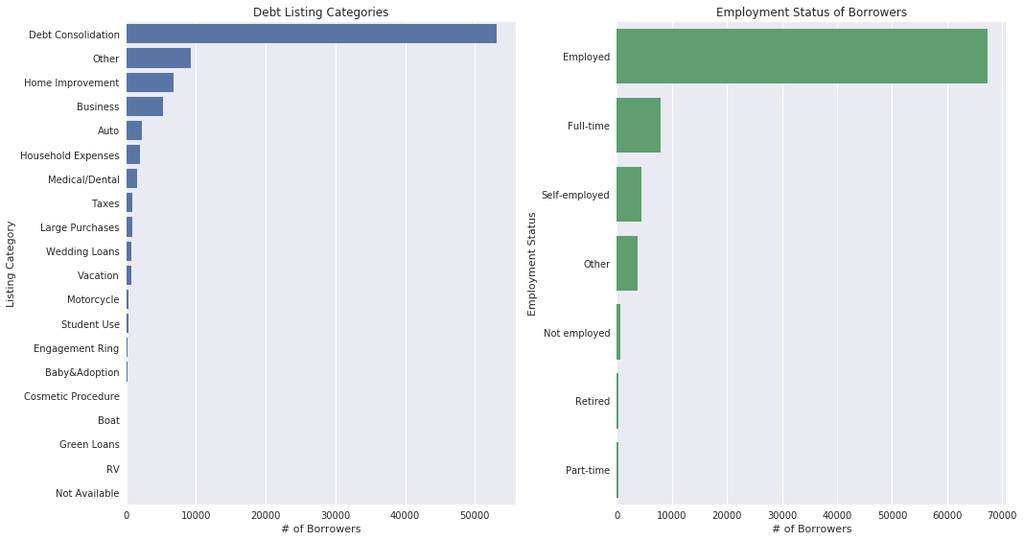

```python
plt.figure(figsize = (15,8))
# Plot for ListingCategory
base_color = sb.color_palette()[0]
# Order the categorical variable type
cat_order = data['ListingCategory'].value_counts().index


plt.subplot(1,2,1)
sb.countplot(data = data, y = 'ListingCategory', color = base_color, order=cat_order)
plt.xlabel('# of Borrowers')
plt.ylabel('Listing Category')
plt.title('Debt Listing Categories');


# Plot for EmploymentStatus
base_color = sb.color_palette()[1]
# Order the categorical variable type
cat_order = data['EmploymentStatus'].value_counts().index

plt.subplot(1,2,2)
sb.countplot(data = data, y = 'EmploymentStatus', color = base_color, order=cat_order)
plt.xlabel('# of Borrowers')
plt.ylabel('Employment Status')
plt.title('Employment Status of Borrowers');

plt.tight_layout()
```

## Correlation Matrix

> Medium to Strong relationship between Prosper Score & Interest Rate (BorrowerAPR)

> Medium relationship between Loan Amount and Interest Rate

```
Text(0.5,1,'Correlation Matrix')
```

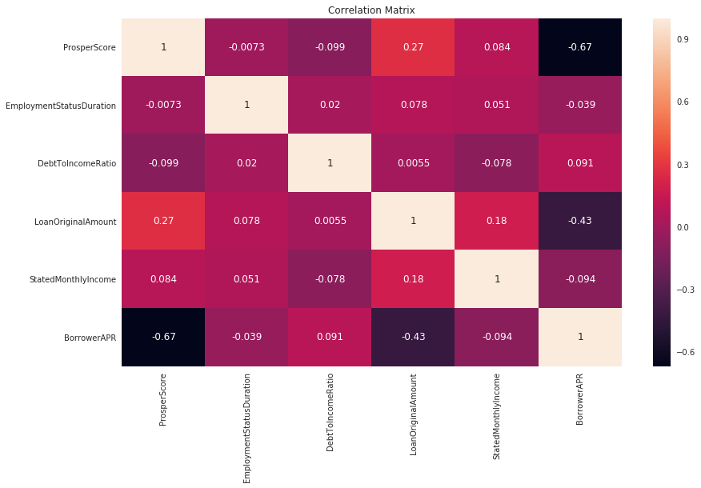

```python
#plotting all numeric variable except Debt to Income ratio as plots won't plot null values
numeric_vars = ['ProsperScore', 'EmploymentStatusDuration','DebtToIncomeRatio', 'LoanOriginalAmount', 'StatedMonthlyIncome', 'BorrowerAPR']

data_numeric = data[numeric_vars]

#First assess the correlation between the numeric variables
plt.figure(figsize = [14, 8])
sb.set()
dataplot=sb.heatmap(data_numeric.corr(), annot=True)
plt.title('Correlation Matrix')
```

## Employment Status On Interest Rate APR

> Applicants that are employed receive a slightly higher loan amount

> While Employment status does not have a strong influence on the interest rate, not being employed will result in a higher interest rate

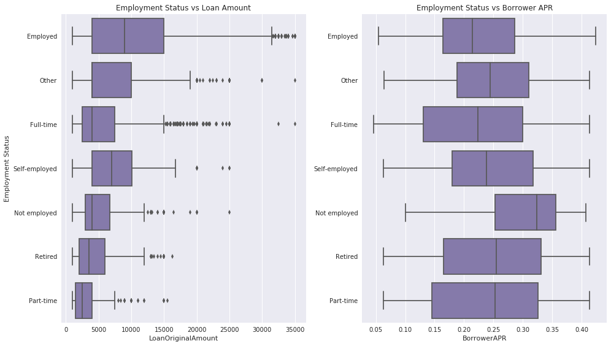

```python
#Assess if employment status has an influence on Borrow APR
plt.figure(figsize = [14, 8])
sb.set()
base_color = sb.color_palette()[3]

plt.subplot(1,2,1)
sb.boxplot(data = data, y = 'EmploymentStatus', x = 'LoanOriginalAmount' ,color = base_color, orient='h')
plt.xticks(rotation = 0)
plt.ylabel('Employment Status')
plt.title('Employment Status vs Loan Amount')

plt.subplot(1,2,2)
sb.boxplot(data = data, y = 'EmploymentStatus', x = 'BorrowerAPR' ,color = base_color, orient='h')
plt.xticks(rotation = 0)
plt.ylabel("")
plt.title('Employment Status vs Borrower APR');

plt.tight_layout()
```

## Loan Amount & Interest Rate APR & Home Owner Relationship

> Larger loans are more likely to have lower intrest rates

> While smaller loans are more variable with the interest rates

> There is no relationship with homeowners getting better interest rates, however more homeowners received larger sized loans

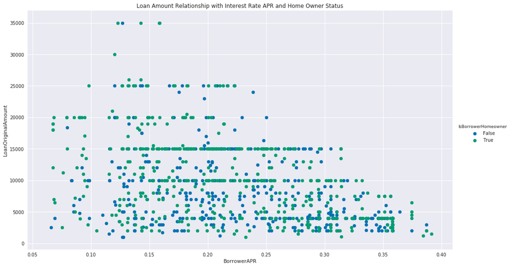

```python
#create a sample of the data, making it easier to plot a Scatter Plot
data_samp = data.sample(1000,replace = False)

sb.set()
g = sb.FacetGrid(data = data_samp, hue = 'IsBorrowerHomeowner', size = 10, palette = 'colorblind')
g.fig.set_size_inches(14, 8)
g.map(plt.scatter, 'BorrowerAPR', 'LoanOriginalAmount')
plt.title('Loan Amount Relationship with Interest Rate APR and Home Owner Status')
g.add_legend()
```

## Loan Amount & Income Range & Home Owner Relationship

> Higher Income applicants get larger loan amounts, with homeowners also get slightly larger loan amounts

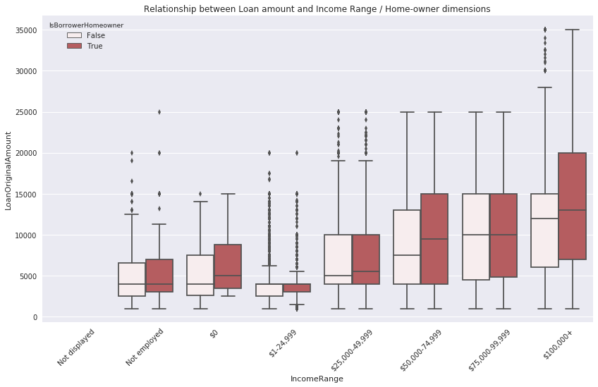

```python
base_color = sb.color_palette()[2]
plt.figure(figsize = [14, 8])
sb.set()
sb.boxplot(data = data, x = 'IncomeRange', y = 'LoanOriginalAmount',hue = 'IsBorrowerHomeowner' ,color = base_color)
plt.title('Relationship between Loan amount and Income Range / Home-owner dimensions')
plt.xticks(rotation = 45);
```

## Conclusion

> Having a good prosper score have a positive influence on the intrest rate an applicant receives on their loan amount.

> Further analysis needs to be done on assessing which variables have the most influence in determining the Prosper Score.